# Final Assignemt - Data Science in Bioinformatics

T Bataillon

November 12, 2018

# Instructions for returning your report

Your report should be uploaded as a **zip** file containing:

- An Rmd file with the answers and comments
- the HTML file you generated from the Rmd file.

**IMPORTANT: Check your zip file and make sure that the html file contains all figures!!!**

**DEADLINE: The upload shoud be done no later than 12.12.2018 at 12.00 (noon).**

After the deadline, a peer-review will be started under black board.

**DEADLINE: The peer review should be done no later than 08.01.2019 at 12.00 (noon).**

You will assigned 3 reports to peer review. You should use 15-20 minutes on each.

**IMPORTANT: Both uploading your report and peer reviewing 3 other reports assigned to you is mandatory to be able to take the exam.**

# Some background and the big picture for this assignment

The goal of this assignment is to replicate some of the findings of a scientific paper:

Shorter et al 2015 Genetic architecture of natural variation in Drosophila melanogaster aggressive behavior, PNAS. Measurements of male aggression have been made for 200 lines out of the 205 lines of the DRGP pannel.

The data is contained is the csv file “aggression.male.csv”.

If you want to “know” more about male aggression in Drosphila and see some [real fights](https://www.youtube.com/watch?v=uJaDoTigvEI).

The idea for this final assignment is to combine the SNP data that you have been working on before with this aggression scores to examine if some SNPs in the genome associate with the variation in aggression scores observed among the Drosohila lines.

When a population is variable for a collection of SNPs and also exhibits variation for a phenotypic trait ( here the aggression score), one can ask if there is a statistical association between a given SNP and the trait in the population.

This will be manifested by the fact that individuals that carry a specfic allele tend, on average, to have a higher (or lower) trait value (one also talks abou ta QTL for Quantitative trait locus, i.e. a locus where polymorphism controls the variation of a quantitative traits (by opposition to a Mendelian trait).

Shorter et al 2015 report several significant associations between SNPs and the aggression scores.

Results of the SNP giving the top associations are given as supplementary table of the PNAS publication made available as (Dataset S2. Genome wide association analyses for aggressive behavior). See the Excel file **pnas.1510104112.sd02.xlsx**

The goals for this final project (see the precise questions below) is :

- Re-analyze jointly the variation found at specific SNPs of the left arm of chromosme 3 (aka 3L)
- Choose and motivate the choice of a method to test for the presence of an association in the data
- Calculate the effect size associated with a SNP for the trait and provide a measure of the uncertainty of the that effect size (e.g. standard error)
- Visualize the association at each specififc SNP tested

# Getting the aggression score data

The Aggression scores are made available for each Drosophila line (identified with lineId) in the csv file *aggression.male.csv*.

```r
library(tidyverse)

#The aggression scores for each line
Pheno        <- read_csv(file = "aggression.male.csv", col_names = FALSE)
names(Pheno) <- c("lineid","aggression_score")

head(Pheno)
```

```
## # A tibble: 6 x 2
##   lineid   aggression_score
##   <chr>               <dbl>
## 1 line_100            25.2
## 2 line_101            15.9
## 3 line_105            19.7
## 4 line_109             9.61
## 5 line_129            31.7
## 6 line_136            24.6
```

```r
dim(Pheno)
```

```
## [1] 200   2
```

> Q1. Vizualizing and summarizing male aggression scores among the lines.

Make a graph displaying the distribution of male aggression scores among the lines.

Summarize the distribution and comment on the general shape of the distribution (bimodal / skewed etc.)

```r
# Multiple plot function, as taken from < http://www.cookbook-r.com/Graphs/Multiple_graphs_on_one_page_(ggplot2)/ >
#
# ggplot objects can be passed in ..., or to plotlist (as a list of ggplot objects)
# - cols:   Number of columns in layout
# - layout: A matrix specifying the layout. If present, 'cols' is ignored.
#
# If the layout is something like matrix(c(1,2,3,3), nrow=2, byrow=TRUE),
# then plot 1 will go in the upper left, 2 will go in the upper right, and
# 3 will go all the way across the bottom.
#
multiplot <- function(..., plotlist=NULL, file, cols=1, layout=NULL) {
  library(grid)

  # Make a list from the ... arguments and plotlist
  plots <- c(list(...), plotlist)

  numPlots = length(plots)

  # If layout is NULL, then use 'cols' to determine layout
  if (is.null(layout)) {
    # Make the panel
    # ncol: Number of columns of plots
    # nrow: Number of rows needed, calculated from # of cols
    layout <- matrix(seq(1, cols * ceiling(numPlots/cols)),
                    ncol = cols, nrow = ceiling(numPlots/cols))
  }

 if (numPlots==1) {
    print(plots[[1]])

  } else {
    # Set up the page
    grid.newpage()
    pushViewport(viewport(layout = grid.layout(nrow(layout), ncol(layout))))

    # Make each plot, in the correct location
    for (i in 1:numPlots) {
      # Get the i,j matrix positions of the regions that contain this subplot
      matchidx <- as.data.frame(which(layout == i, arr.ind = TRUE))

      print(plots[[i]], vp = viewport(layout.pos.row = matchidx$row,
                                      layout.pos.col = matchidx$col))
    }
  }
}
```

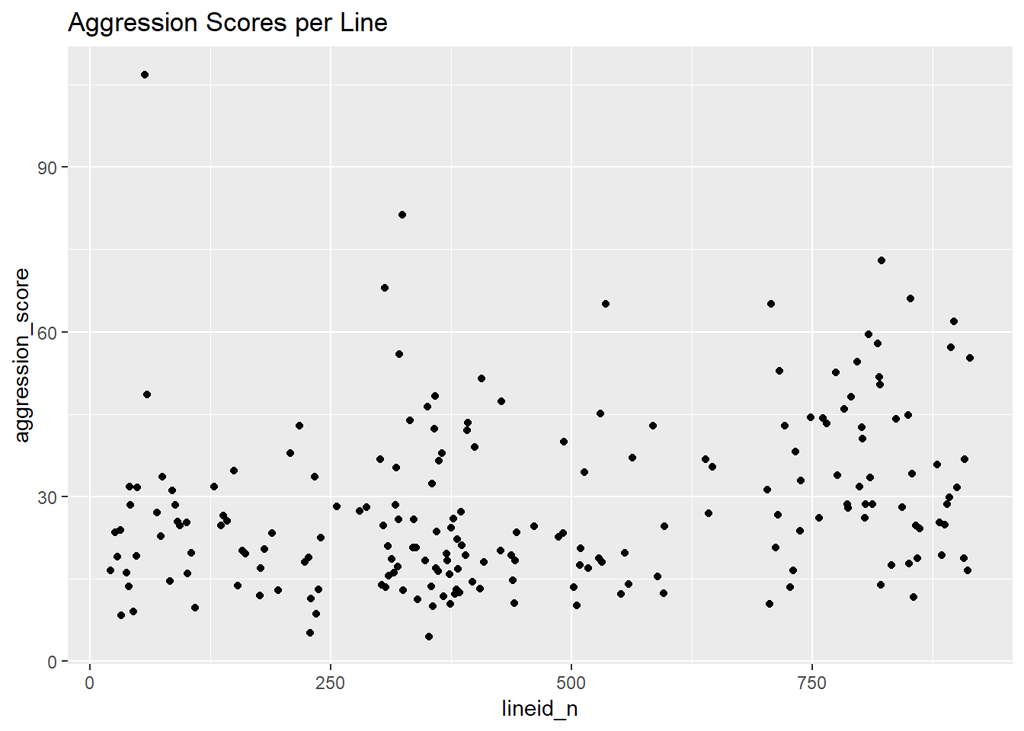

```r
tmp = str_split(Pheno$lineid, '_')
pheno_ord = Pheno
pheno_ord['lineid_n'] = as.integer(matrix(unlist(tmp), ncol=2, byrow=TRUE)[,2])

# Order them by the line id so that we can use breaks in the distribution plot
pheno_ord = pheno_ord[with(pheno_ord, order(lineid_n)),]
tmp = str_split(pheno_ord$lineid, '_')
pheno_ord$lineid = matrix(unlist(tmp), ncol=2, byrow=TRUE)[,2]

# create bins for better visualization
pheno_cuts = cut(pheno_ord$lineid_n, seq(0, 1000, 150))
pheno_ord['bin_id'] = pheno_cuts

ggplot(pheno_ord) + geom_point(mapping= aes(lineid_n, aggression_score)) + ggtitle('Aggression Scores per Line')
```

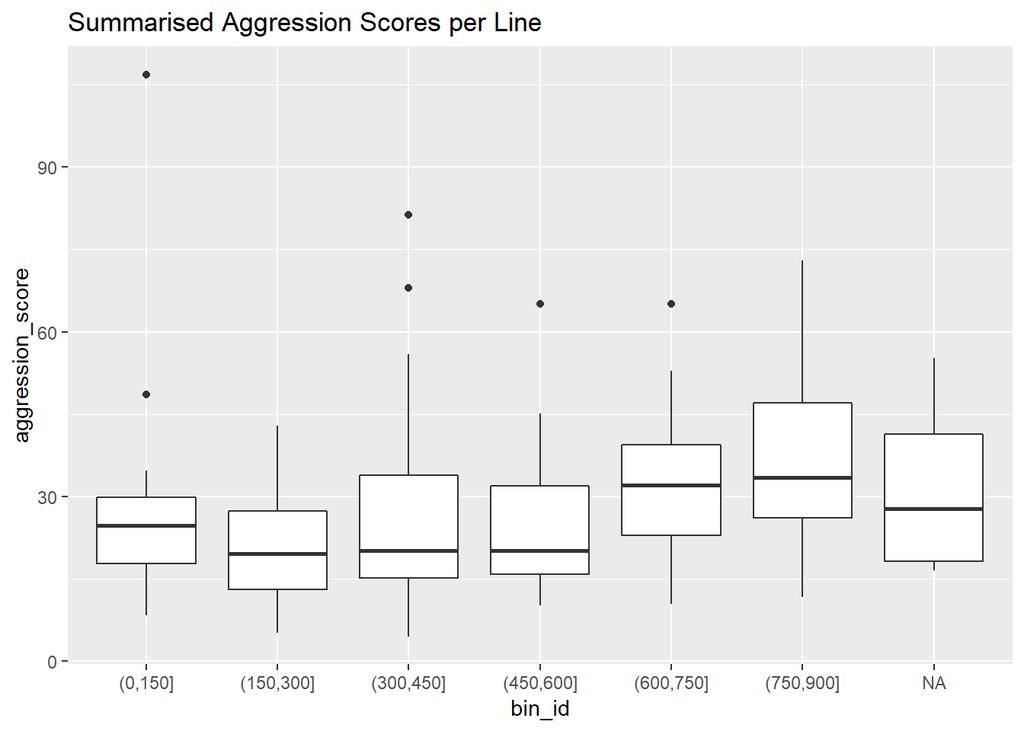

```r
ggplot(pheno_ord) + geom_boxplot(mapping = aes(bin_id, aggression_score)) + ggtitle('Summarised Aggression Scores per Line')
```

The agression over line number has a relatively continuous distribution. This can be seen both in the point plot, and in the box plot.

Looking at the probability distribution of agression scores, we can notice a skewed distribution. Most lines seem to have lower agression scores. There are however some outliers and the right tail is pretty long, showing high agression scores for some lines.

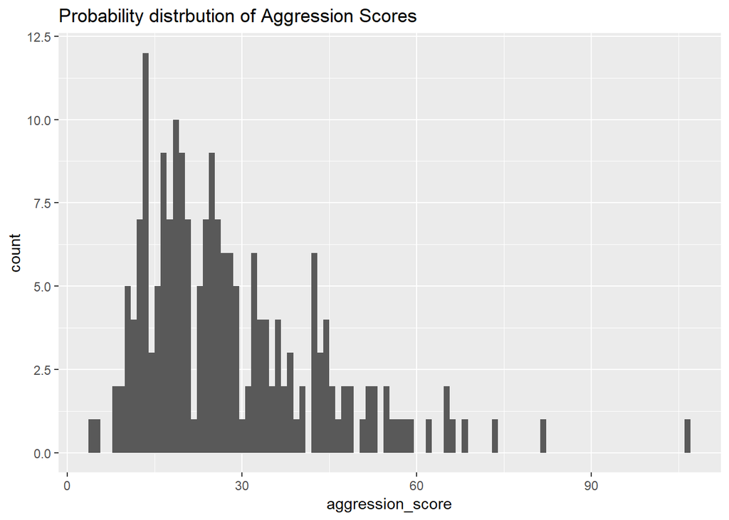

```r
ggplot(pheno_ord) + geom_histogram(mapping = aes(aggression_score), bins = 100) + ggtitle('Probability distrbution of Aggression Scores')
```

> Q2. Preparing the data

Here you should prepare the data to replicate the results of associations detected on chromsome 3L and show the first lines of the result.

Focus on the 4 SNPs reported in the publication that are located on chr 3L and that are showing the most significant association between aggression and SNP genoytpe (as measured by the lowest p-value).

These SNPS are :

- 3L_14313095_SNP
- 3L_9132740_SNP
- 3L_10922119_SNP
- 3L_10922120_SNP

Read in the DRGP genotypes data (dgrp2.tgeno.zip) and build a new dataframe that integrates for each lineID the following information:

- The name of the data frame should be “QTL_df” and the columns have the names indicated below in ()
- The id of the line (lineid)
- The aggression score of the line (Aggression_score)
- A qualitatively defined aggression level defined by the following thresholdsholds (Aggression_level)
  - “LOW” (Aggression < 20)
  - “MEDIUM” (20 <= Aggression < 50)
  - “HIGH” (Aggression >=50)
- The genotype at each SNP and each line, the genotype can be coded by the SNP allele carried or using the 0/2 genotype code (genotype)

End by showing the first lines of your data frame using head()

```
#Reading the data...

wanted_snps = c('3L_14313095_SNP', '3L_9132740_SNP', '3L_10922119_SNP', '3L_10922120_SNP')

f <- function(df, pos) {
  #print(df)

  tt <- df %>%
    filter(id %in% wanted_snps) %>%
    {.}
  #write_csv(tt, "../datasets/dgrp2.3L", append = TRUE) # Log progress to log file

  return(tt)
}

data_file_path = "../datasets/dgrp2.tgeno"

first_2 = read_delim(data_file_path, delim = ' ', n_max = 2)

df_ <- read_delim_chunked(file = data_file_path,
                         callback = ListCallback$new(f),
                         chunk_size = 50000, guess_max = 100,
                         col_names = T, delim = " ", comment = "#",
                         progress = T)
data_3L = bind_rows(df_)
write_csv(data_3L, "../datasets/dgrp2.3L_snps")
```

```r
#Read directly from saved csv
data_3L = read.csv("../datasets/dgrp2.3L_snps")
```

```r
# Transform the data
QTL_df = data_3L %>%
  gather(key = "lineid", value = "genotype", starts_with("line"))
QTL_df = merge(QTL_df, Pheno, by = c('lineid'))
names(QTL_df)[names(QTL_df)=="aggression_score"] <- "Aggression_score"


cat_aggr = function(aggression) {
  ifelse(aggression < 20, 'LOW', ifelse(aggression < 50, 'MEDIUM', 'HIGH'))
}

QTL_df = QTL_df %>% mutate(Aggression_level = cat_aggr(Aggression_score))
keeps = c('genotype', 'id', 'Aggression_score', 'Aggression_level' )
QTL_df = QTL_df[, keeps]
head(QTL_df)
```

```
##   genotype              id Aggression_score Aggression_level
## 1        2 3L_10922119_SNP          25.2116           MEDIUM
## 2        0 3L_14313095_SNP          25.2116           MEDIUM
## 3        0  3L_9132740_SNP          25.2116           MEDIUM
## 4        2 3L_10922120_SNP          25.2116           MEDIUM
## 5        0  3L_9132740_SNP          15.9116              LOW
## 6        0 3L_10922120_SNP          15.9116              LOW
```

> Q3 Measuring and vizualizing the differences in male agression scores at each SNP

For each SNP:

- measure the effect size and SEs associated with this effect for each SNP:

The effect size is here measured as half the difference in mean between each group of genotypes.

$$EffectSize=(Mean_2-Mean_0)/2$$

The half is inherited from quantitative genetic: on average you transmit half of your genes to your offspring so you dilute the genetic effect by that much by mixing/mating at random…

- make a graph comparing the distribution of aggression scores within each group defined by genotype.

A group is here defined by the SNP genotype of each line (i.e. you are 0 or 2, note that some lines could not be genotyped at certain SNPs).

HINT: If we want to have an idea of the SE aroud that effect size, one can use for instance a boostrap approach to automatically get the sampling distribution around the effect size. Remember the definition of standard error.

```r
#* measure the effect size and SEs associated with this effect for each SNP:

# Compute the effect size for each SNP
base_df = QTL_df[c('genotype', 'id', 'Aggression_score')] %>%
  filter(genotype == '0' | genotype == '2') %>%
  group_by(id, genotype)

EffectSize_df = base_df %>%
  summarise(mean_geno = mean(Aggression_score)) %>%
  group_by(id) %>%
  mutate(effect_size = (mean_geno[genotype == '2'] - mean_geno[genotype == '0'])/2)
EffectSize_df = EffectSize_df[,c('id','effect_size')] %>% unique()
```

```
#Bootstrap a distribution to get the SE:
nof_bootstraps = 10^4
total_size = 4 * nof_bootstraps
effect_size_boot = EffectSize_df

for (i in 0:nof_bootstraps){
  rows = sample(1:nrow(base_df), replace = TRUE)
  sample_ = base_df[rows,] %>%
    summarise(mean_geno = mean(Aggression_score)) %>%
    group_by(id)


  sample_effect_size = sample_ %>%
    mutate(effect_size = (mean_geno[genotype == '2'] - mean_geno[genotype == '0'])/2)
  sample_effect_size = sample_effect_size[,c('id','effect_size')] %>% unique()
  effect_size_boot = merge(effect_size_boot, sample_effect_size,  all = TRUE)
  if(i%%(nof_bootstraps/50)==0) {   # Progress tracker
    cat(i, "\n")
    flush.console()
  }
}
summary(effect_size_boot)
write_csv(effect_size_boot, "../datasets/effect_size_boot")
```

```r
effect_size_boot = read_csv("../datasets/effect_size_boot")
```

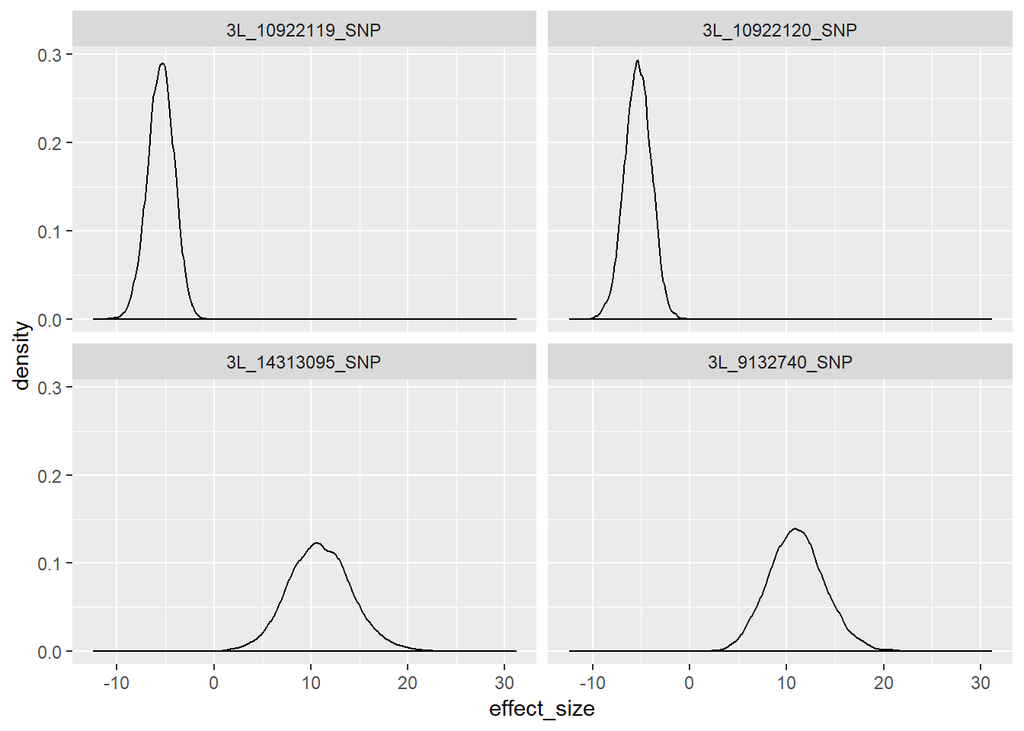

```r
ggplot(effect_size_boot) + geom_density(mapping = aes(effect_size)) +
  facet_wrap(~id)
```

```r
SE = effect_size_boot %>%
  group_by(id) %>%
  summarise(SD = sd(effect_size))
```

The computed standard error is then:

```r
SE
```

```
## # A tibble: 4 x 2
##   id                 SD
##   <chr>           <dbl>
## 1 3L_10922119_SNP  1.36
## 2 3L_10922120_SNP  1.36
## 3 3L_14313095_SNP  3.30
## 4 3L_9132740_SNP   2.91
```

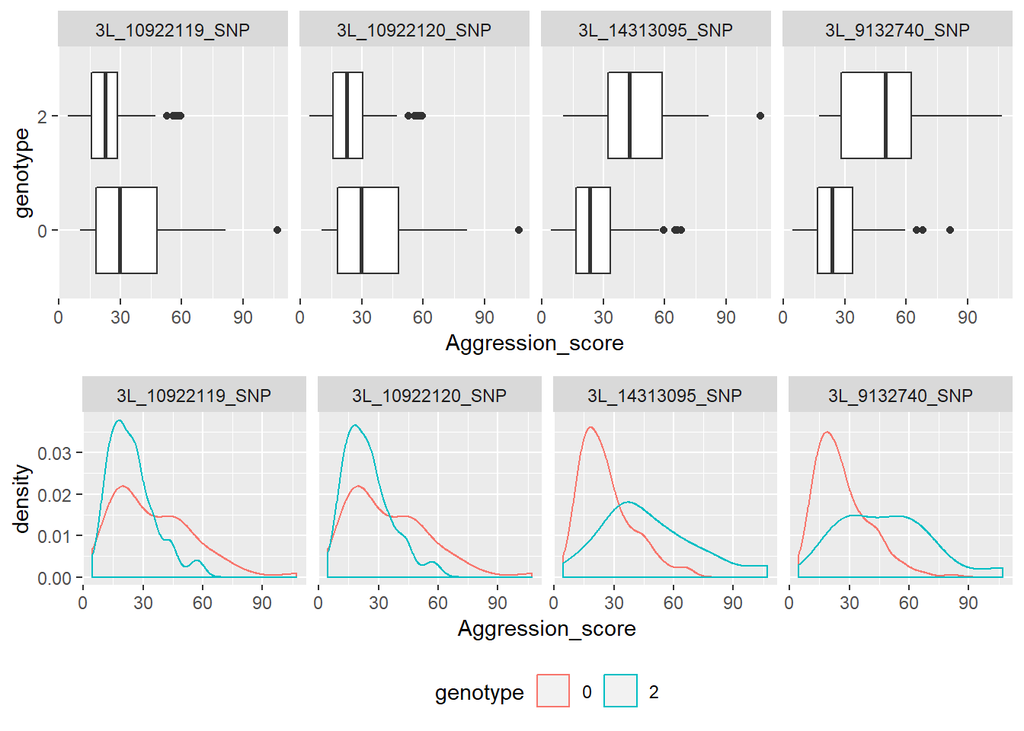

```r
# * make a graph comparing the distribution of aggression scores within each group defined by genotype.

box_plot = QTL_df %>% filter(genotype == '0' | genotype == '2') %>%
  ggplot() + geom_boxplot(mapping = aes(genotype, Aggression_score)) +
  facet_grid(~id) + coord_flip()

density_plot = QTL_df %>% filter(genotype == '0' | genotype == '2') %>%
  ggplot() + geom_density(mapping = aes(Aggression_score, color = genotype)) +
  facet_grid(~id) + theme(legend.position="bottom")

multiplot(box_plot, density_plot)
```

> Q4. Testing if there is an association between SNPs and the aggression score or level

Now you are familiar with the overall distribution of the aggression scores and how the data is also distributed between groups (groups being defined by genotypes at a given SNP).

Based on that knowledge:

- choose (and justify your choice) a method to test if there is a significant association between the SNP genotype and the aggression score or level for each SNP.
- apply this method and show your results
- explain and conclude on the results of your analysis

You are free to chose whether your will use the aggression score or the aggression level as the “aggression” variable.

Answer:

I’ve choosen to test the association between SNP genotype and agression score using linear models. This is because, as we can see in the previous graphs, it is the interraction between genotype and specific SNP which affects the agression score. We can see this in the following plots (and Anova test results)

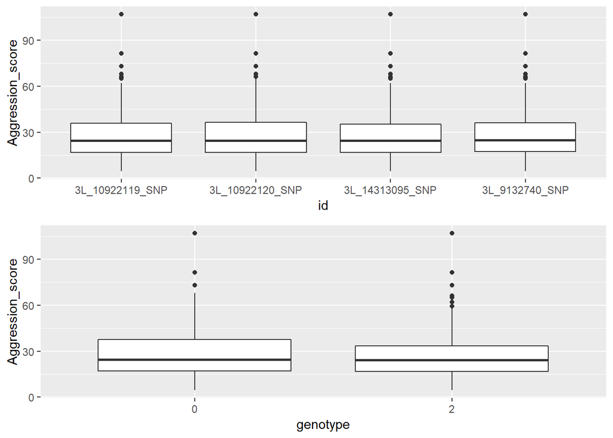

```r
id_plot = QTL_df %>% filter(genotype == '0' | genotype == '2') %>%
  ggplot() + geom_boxplot(mapping = aes(id, Aggression_score))

geno_plot = QTL_df %>% filter(genotype == '0' | genotype == '2') %>%
  ggplot() + geom_boxplot(mapping = aes(genotype, Aggression_score))

multiplot(id_plot, geno_plot)
```

As you can see, there is not much variation when taking the individual SNP or genotypes. But there is an interraction between the two which affects the aggression score, as it can be seen by the results from the following Anova tests:

H0 = There is no association between genotype*SNP and Aggression_score

Ha = there is association between genotype*SNP and Aggression_score

```r
library(car)

id_to_int = function (id) {
  ifelse(id == '3L_14313095_SNP', 0, ifelse(id == '3L_9132740_SNP', 1, ifelse(id == '3L_10922119_SNP', 2, 3)))
}

test_df = QTL_df[c('Aggression_score', 'genotype', 'id')] %>%
  filter(genotype == '0' | genotype == '2') %>%
  mutate(geno_int = as.integer(genotype), id_int = id_to_int(id))

Anova(lm(Aggression_score ~ geno_int + id_int, data = test_df), type = "III")
```

```
## Anova Table (Type III tests)
##
## Response: Aggression_score
##             Sum Sq  Df  F value  Pr(>F)
## (Intercept) 216536   1 884.4790 < 2e-16 ***
## geno_int       763   1   3.1146 0.07799 .
## id_int         273   1   1.1160 0.29112
## Residuals   188020 768
## ---
## Signif. codes:  0 '***' 0.001 '**' 0.01 '*' 0.05 '.' 0.1 ' ' 1
```

```r
Anova(lm(Aggression_score ~ geno_int * id_int, data = test_df), type = "III")
```

```
## Anova Table (Type III tests)
##
## Response: Aggression_score
##                 Sum Sq  Df F value    Pr(>F)
## (Intercept)     150639   1 667.311 < 2.2e-16 ***
## geno_int          9065   1  40.157 3.994e-10 ***
## id_int            5934   1  26.287 3.729e-07 ***
## geno_int:id_int  14877   1  65.903 1.883e-15 ***
## Residuals       173143 767
## ---
## Signif. codes:  0 '***' 0.001 '**' 0.01 '*' 0.05 '.' 0.1 ' ' 1
```

As you can see, the first Anova test (without interraction) accepts the null Hypothesis as expected. But when the interraction term geno_int * id_int is added, the null hypothesis can be rejected due to a small value of P. Therefore we can conclude that there actually is an association between genotypes SNPs and the Aggression levels. This can be double checked by generating a NULL sample distribution (via permutations) for the data. Then the slopes of the fit can be compared with the observed slope and see if there is indeed correlation or not.

Another option is to use a non-parametric spearman test and taking each SNP individually.

```r
test_df %>%
  group_by(id) %>%
  summarise(p_val = cor.test(Aggression_score, geno_int, method = 'spearman')$p.value)
```

```
## # A tibble: 4 x 2
##   id                  p_val
##   <fct>               <dbl>
## 1 3L_10922119_SNP 0.000417
## 2 3L_10922120_SNP 0.000599
## 3 3L_14313095_SNP 0.000126
## 4 3L_9132740_SNP  0.0000317
```

This again results in low p values, so we can reject the null hypothesis.

**IMPORTANT: Make sure you read the upload instructions at the top of this document!!!**